# Introduction to SC19020

## Answer of 7.10

1.basic ideas

Cross validation and adjusted R square are applied to select the best regression model

2.code

```r
library(DAAG)
attach(ironslag)
n <- length(magnetic)
e1 <- e2 <- e3 <- e4 <- numeric(n)
#for n-fold cross validation
for (i in 1:n) {
  y <- magnetic[-i]
  x <- chemical[-i]
#Fit the model(s) using only the n−1 observations in the training set
#Compute the predicted response for the test point
#Compute the prediction error

  M1 <- lm(y ~ x) #linear model
  yhat1 <- M1$coef[1]+M1$coef[2]*chemical[i]
  e1[i] <- magnetic[i] - yhat1

  M2 <- lm(y ~ x + I(x^2)) #quadratic polynomial model
  yhat2 <- M2$coef[1]+M2$coef[2]*chemical[i]+M2$coef[3]*chemical[i]^2
  e2[i] <- magnetic[i] - yhat2

  M3 <- lm(log(y) ~ x) #exponential model
  logyhat3 <- M3$coef[1]+M3$coef[2]*chemical[i]
  yhat3 <- exp(logyhat3)
  e3[i] <- magnetic[i] - yhat3

  M4 <- lm(y ~ x + I(x^2)+I(x^3)) #cubic polynomial model
  yhat4 <- M4$coef[1]+M4$coef[2]*chemical[i]+M4$coef[3]*chemical[i]^2+M4$coef[4]*chemical[i]^3
  e4[i] <- magnetic[i] - yhat4
}
#calculate the average squared prediction error
 c(mean(e1^2), mean(e2^2), mean(e3^2), mean(e4^2))
```

```
## [1] 19.55644 17.85248 18.44188 18.17756
```

```r
#print the adjusted R squares
 c(summary(M1)$adj.r.squared, summary(M2)$adj.r.squared, summary(M3)$adj.r.squared, summary(M4)$adj.r.squared)
```

```
## [1] 0.5319104 0.5909726 0.5283260 0.5937184
```

3.my thoughts

According to the cross validation procedure, we should choose the quadratic polynomial model. However, according to maximum adjusted R square, we should choose the cubic polynomial model.

### Homework of 20191122

## Question

8.3 The Count 5 test for equal variances in Section 6.4 is based on the maximum number of extreme points. Example 6.15 shows that the Count 5 criterion is not applicable for unequal sample sizes. Implement a permutation test for equal variance based on the maximum number of extreme points that applies when sample sizes are not necessarily equal.

Ex: Power comparison (distance correlation test versus ball covariance test)

Model 1: $Y=X/4+e$; Model 2: $Y=X/4\times e$

where $X\sim N\left(0_{2},I_{2}\right)$, $e\sim N\left(0_{2},I_{2}\right)$, $X$ and $e$ are independent.

## Answer of 8.3

1.basic ideas

In order to overcome the problem we met in eg 6.15, we can use permutation to generate samples with equal sizes and then compute the Count Five statistic.

2.code

```r
set.seed(12345)
## count5 function
count5test <- function(x, y) {
  X <- x - mean(x)
  Y <- y - mean(y)
  outx <- sum(X > max(Y)) + sum(X < min(Y))
  outy <- sum(Y > max(X)) + sum(Y < min(X))
  # return 1 (reject) or 0 (do not reject H0)
  return(as.integer(max(c(outx, outy)) > 5))
}
## generate samples with unequal sizes and same variance
n1 <- 20; n2 <- 30; N <- n1 + n2
mu1 <- mu2 <- 0; sigma1 <- sigma2 <- 1
x <- rnorm(n1,mu1,sigma1); y <- rnorm(n2,mu2,sigma2)

#use permutation to estimate t1e with sample size of 20 and 30
z <- c(x,y); R <- 9999; t <- numeric(R)
for (i in 1:R) {
  k <- sample(1:N, size = N/2, replace = FALSE)
  x1 <- z[k]; y1 <- z[-k] # a new group of X and Y with the same size
  t[i] <- count5test(x1,y1)
}
p1 <- mean(t)# t1e

#generate another group of samples with sample size of 20 and 50
n1 <- 20; n2 <- 50; N <- n1+n2
mu1 <- mu2 <- 0; sigma1 <- sigma2 <- 1
x <- rnorm(n1,mu1,sigma1); y <- rnorm(n2,mu2,sigma2)

#use permutation to estimate t1e
z <- c(x,y); R <- 9999; t <- numeric(R)
for (i in 1:R) {
  k <- sample(1:N, size = N/2, replace = FALSE)
  x1 <- z[k]; y1 <- z[-k] # a new group of X and Y with the same size
  t[i] <- count5test(x1,y1)
}
p2 <- mean(t)# t1e

# use Mento carlo method to estimate the empirical t1e with sample size of 20 and 50
p <- numeric(100)
for(j in 1:100){
  x <- rnorm(n1,mu1,sigma1); y <- rnorm(n2,mu2,sigma2)

  z <- c(x,y); R <- 9999; t <- numeric(R)
  for (i in 1:R) {
    k <- sample(1:N, size = N/2, replace = FALSE)
    x1 <- z[k]; y1 <- z[-k]
    t[i] <- count5test(x1,y1)
  }
  p[j] <- mean(t)
}
p3 <- mean(p)# empirical t1e

# print the result
round(c(p1=p1,p2=p2,p3=p3),3)
```

```
##    p1    p2    p3
## 0.051 0.065 0.072
```

3.my thoughts

We can find that the result is quite good. When sample sizes are 20 and 30, we improve the original value in eg 6.15 from 0.1064 to 0.051, and when sample sizes are 20 and 50, we improve it from 0.2934 to 0.065.

I use Mento Carlo method to repeat the simulation above with n1 = 20 and n2 = 50, and I get the empirical t1e (0.072), which is quite good compared with the original t1e in eg 6.15.

As a result, the method with permutation is applicable for unequal sample sizes.

## Answer of Ex

1.basic ideas

Use distance correlation test and ball covariance test to do independence hypothesis test of two different models, and use Mento Carlo method to estimate the powers and compare them with each other.

2.code

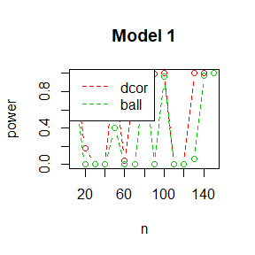

```r
set.seed(12345)
library(mvtnorm); library(Ball); library(boot)
seed <- 12345; m <- 1e2
mean <- c(0,0); sigma <- matrix(c(1,0,0,1),nrow =2)
## the statistic of distance correlation test
DCOR <- function(z,ix,dims) {
  p <- dims[1]
  q <- dims[2]
  d <- p + q
  x <- as.matrix(z[ , 1:p])
  y <- as.matrix(z[ix, -(1:p)])
  n <- nrow(x)
  m <- nrow(y)
  if (n != m || n < 2) stop("Sample sizes must agree")
  if (! (all(is.finite(c(x, y)))))
    stop("Data contains missing or infinite values")
  Akl <- function(x) {
    d <- as.matrix(dist(x))
    m <- rowMeans(d); M <- mean(d)
    a <- sweep(d, 1, m); b <- sweep(a, 2, m)
    b + M
  }
  A <- Akl(x)
  B <- Akl(y)
  dCov <- mean(A * B)
  dVarX <- sqrt(mean(A * A))
  dVarY <- sqrt(mean(B * B))
  dCor <- dCov / sqrt(dVarX * dVarY)
  return(dCor)
}

N <- seq(10, 150, by=10)# different sample sizes
power11 <- power12 <- power21 <- power22 <- numeric(length(N))
alpha <- 0.05

## model 1
## Mento Carlo Method
for(i in 1:length(N)){
  X1 <- rmvnorm(N[i],mean,sigma); e1 <- rmvnorm(N[i],mean,sigma)
  Y1 <- X1/4+e1 #generate samples
  z <- cbind(X1,Y1); z1 <- as.matrix(z)

  p.values <- matrix(NA,m,2)

  for(j in 1:m){
    boot.obj <- boot(data = z1, statistic = DCOR, R = 99, sim ="permutation", dims = c(2, 2))# distance correlation test with permutation
    tb <- c(boot.obj$t0, boot.obj$t)
    p.values[j,1] <- mean(tb >= tb[1])

    p.values[j,2] <- bcov.test(X1,Y1,R=99,seed=j*seed)$p.value# ball covariance test
    }
  power11[i] <- colMeans(p.values < alpha)[1]
  power12[i] <- colMeans(p.values < alpha)[2]
}
## draw the graph about powers of two testing methods with model 1
par <- par(no.readonly = TRUE)
plot(N,power11,type = "b",xlab="n",ylab="power",main="Model 1",lty=2,col=2)
lines(N,power12,type="b",lty=2,col=3)
legend("topleft", legend = c("dcor", "ball"), col = 2:3,lty = c(2,2))
```

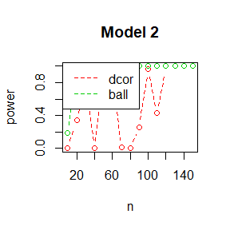

```r
## model 2 (the same process with model 1)
for(i in 1:length(N)){
  X2 <- rmvnorm(N[i],mean,sigma); e2 <- rmvnorm(N[i],mean,sigma)
  Y2 <- (X2/4)*e2
  z <- cbind(X2,Y2); z2 <- as.matrix(z)

  p.values <- matrix(NA,m,2)
  for(j in 1:m){
    boot.obj <- boot(data = z2, statistic = DCOR, R = 99, sim = "permutation", dims = c(2, 2))
    tb <- c(boot.obj$t0, boot.obj$t)
    p.values[j,1] <- mean(tb>=tb[1])

    p.values[j,2] <- bcov.test(X2,Y2,R=99,seed=j*seed)$p.value
    }
  power21[i] <- colMeans(p.values < alpha)[1]
  power22[i] <- colMeans(p.values < alpha)[2]
}

plot(N,power21,type = "b",xlab="n",ylab="power",main="Model 2",lty=2,col=2)
lines(N,power22,type="b",lty=2,col=3)
legend("topleft", legend = c("dcor", "ball"), col = 2:3,lty = c(2,2))
```

3.my thoughts

We can find that, in model 1, the power of distance correlation test is not less than the ball covariance test, which means distance correlation test is more suitable for model 1.

However, in model 2, the power of ball covariance test is not less than the distance correlation test, which means ball covariance test is more suitable for model 2.

All in a word, for different models, we should choose different testing method in order to get the best result.

### Homework of 20191129

## Question

9.4 Implement a random walk Metropolis sampler for generating the standard Laplace distribution (see Exercise 3.2). For the increment, simulate from a normal distribution. Compare the chains generated when different variances are used for the proposal distribution. Also, compute the acceptance rates of each chain.

## Answer of 9.4

1.basic ideas

First we can calculate that, the CDF of Laplace distribution is
$$F(x)=\left\{\begin{array}{ll}{\frac{1}{2} e^{x},} & {x<0} \\ {1-\frac{1} {2}e^{-x}} & {, x \geq 0}\end{array}\right.$$
We then implement a random walk Metropolis sampler for generating the standard Laplace distribution and compare them.

2.code

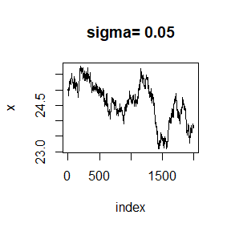

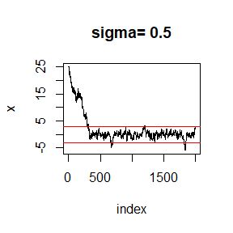

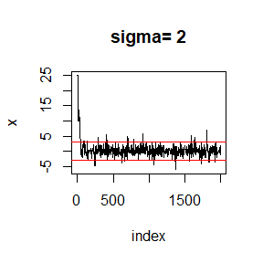

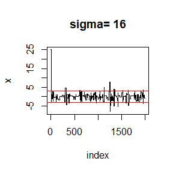

```r
set.seed(12345)
## random walk Metropolis sampler
rw.Metropolis <- function(sigma, x0, N) {
  x <- numeric(N)
  x[1] <- x0
  u <- runif(N)
  k <- 0
  for (i in 2:N) {
    y <- rnorm(1, x[i-1], sigma)
    if (u[i] <= ((1/2)*exp(-abs(y))) / ((1/2)*exp(-abs(x[i-1]))))
      x[i] <- y else {
        x[i] <- x[i-1]
        k <- k + 1
      }
  }
  return(list(x=x, k=k))
}

## samples generated by random walk Metropolis sampler with proposal distributions of different variances
N <- 2000; sigma <- c(0.05, 0.5, 2, 16); x0 <- 25
rw1 <- rw.Metropolis(sigma[1], x0, N)
rw2 <- rw.Metropolis(sigma[2], x0, N)
rw3 <- rw.Metropolis(sigma[3], x0, N)
rw4 <- rw.Metropolis(sigma[4], x0, N)

## plots of four chains
index <- 1:2000
refline <- c(log(2*0.025), -log(2*(1-0.975)))
for(i in 1:4){
  y <- rw.Metropolis(sigma[i], x0, N)$x
  plot(index,y,type = "l",ylab="x")
  abline(h=refline,lwd=1,col=2)
  title(paste("sigma=",sigma[i]))
}
```

```r
## compare the quantiles
alpha <- seq(0.05,0.95,by=0.05)
Q <- c(log(2*alpha[1:10]), -log(2*(1-alpha[11:19])))# the true quantiles of Lapalace disribution
rw <- cbind(rw1$x, rw2$x, rw3$x, rw4$x)
mc <- rw[401:N, ]
Qrw <- apply(mc,2,function(x) quantile(x, alpha))# the sample quantiles of the four chains
qq <- data.frame(round(cbind(Q, Qrw), 3))
names(qq) <- c('True','sigma=0.05','sigma=0.5','sigma=2','sigma=16')
print(qq)
```

```
##       True sigma=0.05 sigma=0.5 sigma=2 sigma=16
## 5%  -2.303     20.361    -2.621  -2.402   -2.230
## 10% -1.609     20.449    -1.851  -1.636   -1.424
## 15% -1.204     20.518    -1.258  -1.216   -1.043
## 20% -0.916     20.565    -0.923  -0.925   -0.888
## 25% -0.693     20.616    -0.672  -0.714   -0.758
## 30% -0.511     20.685    -0.463  -0.543   -0.653
## 35% -0.357     20.749    -0.314  -0.385   -0.592
## 40% -0.223     20.842    -0.181  -0.268   -0.468
## 45% -0.105     20.985    -0.105  -0.158   -0.379
## 50%  0.000     21.578     0.003  -0.014   -0.304
## 55%  0.105     21.749     0.103   0.110   -0.101
## 60%  0.223     21.915     0.234   0.274    0.066
## 65%  0.357     22.096     0.370   0.390    0.355
## 70%  0.511     22.199     0.505   0.529    0.490
## 75%  0.693     22.300     0.740   0.652    0.606
## 80%  0.916     22.447     0.991   0.816    0.806
## 85%  1.204     22.796     1.293   1.041    0.871
## 90%  1.609     22.976     1.742   1.363    1.210
## 95%  2.303     23.133     2.577   1.939    1.972
```

```r
## acceptance rates
print(c(acceptRate1=1-rw1$k/N, acceptRate2=1-rw2$k/N, acceptRate3=1-rw3$k/N, acceptRate4=1-rw4$k/N))
```

```
## acceptRate1 acceptRate2 acceptRate3 acceptRate4
##      0.9825      0.8300      0.5210      0.1085
```

3.my thoughts

In the first plot, the increments are small and the chain is almost like a true random walk although its acceptance is very high.

The second and third chain converge to the target distribution after a short burn-in period of less than 400 and their quantiles are close to the true distribution. Besides, they have an acceptance rate higher than 0.5.

The fourth chain converges and its quantiles are close to the true distribution, but it is inefficient because the acceptance rate is just 0.1085.

### Homework of 20191206

## Question

11.1 The natural logarithm and exponential functions are inverses of each other, so that mathematically $log(e^x) = e^{log(x)}=x$. Show by example that this property does not hold exactly in computer arithmetic. Does the identity hold with near equality? (See all.equal.)

11.5 Write a function to solve the equation
$$\frac{2 \Gamma\left(\frac{k}{2}\right)}{\sqrt{\pi(k-1)} \Gamma\left(\frac{k-1}{2}\right)}\int_{0}^{c_{k-1}}\left(1+\frac{u^{2}}{k-1}\right)^{-k / 2} d u$$
$$= \frac{2 \Gamma\left(\frac{k+1}{2}\right)}{\sqrt{\pi k} \Gamma\left(\frac{k}{2}\right)}\int_{0}^{c_{k}}\left(1+\frac{u^{2}}{k}\right)^{-(k+1) / 2} d u$$
for $a$, where
$$c_{k}=\sqrt{\frac{a^{2} k}{k+1-a^{2}}}$$
Compare the solutions with the points $A(k)$ in Exercise 11.4.

Ex. A-B-O blood type problem

Let the three alleles be A, B, and O with allele frequencies p, q, and r. The 6 genotype frequencies under HWE and complete counts are as follows.
$$\begin{array}{|c|c|c|c|c|c|}\hline \text { Genotype } & {A A} & {B B} & {O O} & {A O} & {B O} & {A B} & {S u m} \\ \hline \text { Frequency } & {p^{2}} & {q^{2}} & {r^{2}} & {2 p r} & {2 q r} & {2 p q} & {1} \\ \hline \text { Count } & {n _{A A}} & {n _{B B}} & {n _{O O}} & {n_ {A O}} & {n _{B O}} & {n_{ A B}} & {n} \\ \hline\end{array}$$
Observed data: nA· =nAA +nAO =28 (A-type), nB· =nBB +nBO =24 (B-type), nOO =41 (O-type), nAB =70 (AB-type).

Use EM algorithm to solve MLE of p and q (consider missing data nAA and nBB). Show that the log-maximum likelihood values in M-steps are increasing via line plot.

## Answer of 11.1

1.basic ideas

Mathematical calculation is not computational calculation for base 2 representation is used in computer arithmetic. We use “isTRUE” to compare two numbers to see whether they are equal exactly and use “all.equal” to see whether they are equal nearly.

2.code

```r
isTRUE(exp(log(0.1))==log(exp(0.1))); isTRUE(exp(log(0.1))==0.1); isTRUE(log(exp(0.1))==0.1)
```

```
## [1] FALSE
```

```
## [1] FALSE
```

```
## [1] FALSE
```

```r
isTRUE(all.equal(exp(log(0.1)),log(exp(0.1)))); isTRUE(all.equal(exp(log(0.1)),0.1)); isTRUE(all.equal(log(exp(0.1)),0.1))
```

```
## [1] TRUE
```

```
## [1] TRUE
```

```
## [1] TRUE
```

3.conclusion

The identity $log(e^x) = e^{log(x)}=x$ does not hold exactly in computer arithmetic, however, it holds with near equality.

## Answer of 11.5

1.basic ideas

We use function “uniroot” to calculate the roots of two equations in 11.4 and 11.5 with different values of parameter k and compare them.

2.code

```r
## answer of 11.4
k <- c(4:25,100,500,1000)# different values of parameter k (df of t distribution)
solution1 <- numeric(length(k))
for(i in 1:length(k)){
# the one-dimensional nonlinear function
  f <- function(a) {pt(sqrt(a^2*(k[i]-1)/(k[i]-a^2)),k[i]-1)-pt(sqrt(a^2*k[i]/(k[i]+1-a^2)),k[i])}
  solution1[i] <- uniroot(f,lower=0+1e-6,upper=sqrt(k[i])-1e-6)$root
}
round(solution1,4)
```

```
##  [1]  1.4921  1.5335  1.5628  1.5844  1.6012  1.6145  1.6254  1.6344  1.6420
## [10]  1.6485  1.6542  1.6591  1.6634  1.6673  1.6707  1.6738  1.6766  1.6791
## [19]  1.6815  4.7958  4.8990  5.0000 10.0000 22.3607 31.6228
```

```r
## answer of 11.5
k <- c(4:25,100,500,1000)
solution2 <- numeric(length(k))
for(i in 1:length(k)){
# the upper value of integrate function
  ck1 <- function(a) sqrt(a^2*(k[i]-1)/(k[i]-a^2))
# the left function of the equation
  g1 <- function(a) 2*exp(lgamma(k[i]/2)-log(sqrt(pi*(k[i]-1)))-lgamma((k[i]-1)/2))*(integrate(function(u) {(1+u^2/(k[i]-1))^(-k[i]/2)},lower = 1e-6,upper = ck1(a)-1e-6)$value)
  ck2 <- function(a) sqrt(a^2*(k[i])/(k[i]+1-a^2))
  g2 <- function(a) 2*exp(lgamma((k[i]+1)/2)-log(sqrt(pi*k[i]))-lgamma(k[i]/2))*(integrate(function(u) {(1+u^2/(k[i]))^(-(k[i]+1)/2)},lower = 1e-6,upper = ck2(a)-1e-6)$value)

  # the one-dimensional nonlinear function
  f <- function(a) {g1(a)-g2(a)}
  solution2[i] <- uniroot(f,lower=0+1e-2,upper=sqrt(k[i])-1e-2)$root
}
round(solution2,4)
```

```
##  [1] 1.4921 1.5336 1.5627 1.5844 1.6012 1.6145 1.6254 1.6344 1.6420 1.6486
## [11] 1.6542 1.6591 1.6635 1.6673 1.6707 1.6738 1.6766 1.6791 1.6815 1.6836
## [21] 1.6855 1.6874 1.7206 1.7297 1.7309
```

3.my thoughts

We can find that when k is not large, the roots of the two equantions in 11.4 and 11.5 are the same, however, when k is larger than 22, the roots of 11.4 are wrong, which is because computer can not calculate numbers too large.

As a result, we can use $exp(log(x))=x$ to calculate the ratio of two large numbers and improve the algorithm of 11.5 to get the true answers.

## Answer of Ex

1.basic ideas

We use the EM (Expectation–Maximization) algorithm to ﬁnd maximum likelihood estimates when data are incomplete.

2.code

```r
library("stats4")
## the log likelihood function
ll <- function(p,nAA,nBB) -{nAA*log(p[1]^2)+nBB*log(p[2]^2)+41*log((1-p[1]-p[2])^2)+(28-nAA)*log(2*p[1]*(1-p[1]-p[2]))+(24-nBB)*log(2*p[2]*(1-p[1]-p[2]))+70*log(2*p[1]*p[2])}
tol <- 1e-10# convergence condition
N <- 100# max numbers of iterations
lmlv <- numeric(N)# log-maximum likelihood values
p <- c(0.1,0.1)# initial estimate of the target parameter
par <- matrix(nrow= N ,ncol = 2); par[1,] <- p
for(i in 1:N){
  # the E step
  nAA <- 28*p[1]^2/(p[1]^2+2*p[1]*(1-p[1]-p[2]))
  nBB <- 24*p[2]^2/(p[2]^2+2*p[2]*(1-p[1]-p[2]))
  lmlv[i]<-ll(p,nAA,nBB)
  # the M step
  par[i+1,] <- optim(par=p,fn=ll,nAA=nAA,nBB=nBB)$par
  p <- par[i+1,]
  if (sum(abs(par[i+1,]-par[i,])) < tol) break
}
print(round(c(p_mle=p[1],q_mle=p[2]),5))# MLE of p and q
```

```
##   p_mle   q_mle
## 0.32735 0.31040
```

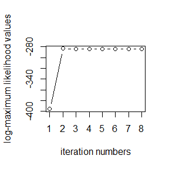

```r
index <- c(1:i)
plot(index,-lmlv[index],type="b",ylab="log-maximum likelihood values",xlab="iteration numbers")
```

3.my thoughts

The MLE of p is 0.32735 and the MLE of q is 0.31040 by EM algorithm and we can find that the log-maximum likelihood values in M-steps are increasing via the line plot.

### Homework of 20191213

### 11.1.2 Exercises

## Question 3

Use both for loops and lapply() to ﬁt linear models to the mtcars using the formulas stored in this list:

formulas <- list( mpg ~ disp, mpg ~ I(1 / disp), mpg ~ disp + wt, mpg ~ I(1 / disp) + wt)

## Answer

```r
attach(mtcars)
formulas <- list( mpg ~ disp, mpg ~ I(1 / disp), mpg ~ disp + wt, mpg ~ I(1 / disp) + wt)

## for loops
for(i in seq_along(formulas)){
  print(lm(formulas[[i]]))
}
```

```
##
## Call:
## lm(formula = formulas[[i]])
##
## Coefficients:
## (Intercept)         disp
##    29.59985     -0.04122
##
##
## Call:
## lm(formula = formulas[[i]])
##
## Coefficients:
## (Intercept)    I(1/disp)
##       10.75      1557.67
##
##
## Call:
## lm(formula = formulas[[i]])
##
## Coefficients:
## (Intercept)         disp           wt
##    34.96055     -0.01772     -3.35083
##
##
## Call:
## lm(formula = formulas[[i]])
##
## Coefficients:
## (Intercept)    I(1/disp)           wt
##      19.024     1142.560       -1.798
```

```r
## lapply
lapply(formulas, lm)
```

```
## [[1]]
##
## Call:
## FUN(formula = X[[i]])
##
## Coefficients:
## (Intercept)         disp
##    29.59985     -0.04122
##
##
## [[2]]
##
## Call:
## FUN(formula = X[[i]])
##
## Coefficients:
## (Intercept)    I(1/disp)
##       10.75      1557.67
##
##
## [[3]]
##
## Call:
## FUN(formula = X[[i]])
##
## Coefficients:
## (Intercept)         disp           wt
##    34.96055     -0.01772     -3.35083
##
##
## [[4]]
##
## Call:
## FUN(formula = X[[i]])
##
## Coefficients:
## (Intercept)    I(1/disp)           wt
##      19.024     1142.560       -1.798
```

```r
detach(mtcars)
```

## Question 4

Fit the model mpg ~ disp to each of the bootstrap replicates of mtcars in the list below by using a for loops and lapply().

Can you do it without an anonymous function?

bootstraps <- lapply(1:10, function(i) {

rows <- sample(1:nrow(mtcars), rep = TRUE)

mtcars[rows, ]

})

## Answer

```r
bootstraps <- lapply(1:10, function(i) {
  rows <- sample(1:nrow(mtcars), rep = TRUE)
  mtcars[rows, ]
  })
## with an anonymous function
# usefor loops
for(i in seq_along(bootstraps)){
  print(lm(bootstraps[[i]]$mpg ~ bootstraps[[i]]$disp))
}
```

```
##
## Call:
## lm(formula = bootstraps[[i]]$mpg ~ bootstraps[[i]]$disp)
##
## Coefficients:
##          (Intercept)  bootstraps[[i]]$disp
##             29.29223              -0.04465
##
##
## Call:
## lm(formula = bootstraps[[i]]$mpg ~ bootstraps[[i]]$disp)
##
## Coefficients:
##          (Intercept)  bootstraps[[i]]$disp
##             34.14296              -0.05453
##
##
## Call:
## lm(formula = bootstraps[[i]]$mpg ~ bootstraps[[i]]$disp)
##
## Coefficients:
##          (Intercept)  bootstraps[[i]]$disp
##             28.50452              -0.03772
##
##
## Call:
## lm(formula = bootstraps[[i]]$mpg ~ bootstraps[[i]]$disp)
##
## Coefficients:
##          (Intercept)  bootstraps[[i]]$disp
##             29.97980              -0.04506
##
##
## Call:
## lm(formula = bootstraps[[i]]$mpg ~ bootstraps[[i]]$disp)
##
## Coefficients:
##          (Intercept)  bootstraps[[i]]$disp
##             29.08707              -0.03728
##
```

[output cut: 24 more lines]

```
##
## Call:
## lm(formula = bootstraps[[i]]$mpg ~ bootstraps[[i]]$disp)
##
## Coefficients:
##          (Intercept)  bootstraps[[i]]$disp
##             29.26285              -0.03998
##
##
## Call:
## lm(formula = bootstraps[[i]]$mpg ~ bootstraps[[i]]$disp)
##
## Coefficients:
##          (Intercept)  bootstraps[[i]]$disp
##             28.69886              -0.04057
```

```r
# use lapply
lapply(bootstraps, lm, formula = mpg ~ disp)
```

```
## [[1]]
##
## Call:
## FUN(formula = ..1, data = X[[i]])
##
## Coefficients:
## (Intercept)         disp
##    29.29223     -0.04465
##
##
## [[2]]
##
## Call:
## FUN(formula = ..1, data = X[[i]])
##
## Coefficients:
## (Intercept)         disp
##    34.14296     -0.05453
##
##
## [[3]]
##
## Call:
## FUN(formula = ..1, data = X[[i]])
##
## Coefficients:
## (Intercept)         disp
##    28.50452     -0.03772
##
##
## [[4]]
##
## Call:
## FUN(formula = ..1, data = X[[i]])
##
## Coefficients:
## (Intercept)         disp
##    29.97980     -0.04506
##
##
```

[output cut: 43 more lines]

```
## FUN(formula = ..1, data = X[[i]])
##
## Coefficients:
## (Intercept)         disp
##    29.26285     -0.03998
##
##
## [[10]]
##
## Call:
## FUN(formula = ..1, data = X[[i]])
##
## Coefficients:
## (Intercept)         disp
##    28.69886     -0.04057
```

```r
## use lapply without an anonymous function
fit <- function(x){
  lm(mpg ~ disp,data=x)
}
lapply(bootstraps, fit)
```

```
## [[1]]
##
## Call:
## lm(formula = mpg ~ disp, data = x)
##
## Coefficients:
## (Intercept)         disp
##    29.29223     -0.04465
##
##
## [[2]]
##
## Call:
## lm(formula = mpg ~ disp, data = x)
##
## Coefficients:
## (Intercept)         disp
##    34.14296     -0.05453
##
##
## [[3]]
##
## Call:
## lm(formula = mpg ~ disp, data = x)
##
## Coefficients:
## (Intercept)         disp
##    28.50452     -0.03772
##
##
## [[4]]
##
## Call:
## lm(formula = mpg ~ disp, data = x)
##
## Coefficients:
## (Intercept)         disp
##    29.97980     -0.04506
##
##
```

[output cut: 43 more lines]

```
## lm(formula = mpg ~ disp, data = x)
##
## Coefficients:
## (Intercept)         disp
##    29.26285     -0.03998
##
##
## [[10]]
##
## Call:
## lm(formula = mpg ~ disp, data = x)
##
## Coefficients:
## (Intercept)         disp
##    28.69886     -0.04057
```

## Question 5

For each model in the previous two exercises, extract $R^2$ using the function below.

rsq <- function(mod) summary(mod)$r.squared

## Answer

```r
attach(mtcars)
rsq <- function(mod) summary(mod)$r.squared
## R2 in ex3
formulas <- list(mpg ~ disp, mpg ~ I(1 / disp), mpg ~ disp + wt, mpg ~ I(1 / disp) + wt)

# for loops
for(i in seq_along(formulas)){
  print(rsq(lm(formulas[[i]])))
}
```

```
## [1] 0.7183433
## [1] 0.8596865
## [1] 0.7809306
## [1] 0.8838038
```

```r
# lapply
lapply(lapply(formulas,lm),rsq)
```

```
## [[1]]
## [1] 0.7183433
##
## [[2]]
## [1] 0.8596865
##
## [[3]]
## [1] 0.7809306
##
## [[4]]
## [1] 0.8838038
```

```r
## R2 in ex4
bootstraps <- lapply(1:10, function(i) {
  rows <- sample(1:nrow(mtcars), rep = TRUE)
  mtcars[rows, ]
  })

# for loops
for(i in seq_along(bootstraps)){
  print(rsq(lm(bootstraps[[i]]$mpg ~ bootstraps[[i]]$disp)))
}
```

```
## [1] 0.627387
## [1] 0.6173572
## [1] 0.7186893
## [1] 0.7591539
## [1] 0.7737098
## [1] 0.6821303
## [1] 0.7075114
## [1] 0.7445228
## [1] 0.7903234
## [1] 0.8316293
```

```r
# lapply
lapply(lapply(bootstraps, lm, formula = mpg ~ disp),rsq)
```

```
## [[1]]
## [1] 0.627387
##
## [[2]]
## [1] 0.6173572
##
## [[3]]
## [1] 0.7186893
##
## [[4]]
## [1] 0.7591539
##
## [[5]]
## [1] 0.7737098
##
## [[6]]
## [1] 0.6821303
##
## [[7]]
## [1] 0.7075114
##
## [[8]]
## [1] 0.7445228
##
## [[9]]
## [1] 0.7903234
##
## [[10]]
## [1] 0.8316293
```

```r
detach(mtcars)
```

### 11.2.5 Exercises

## Question 3

The following code simulates the performance of a t-test for non-normal data. Use sapply() and an anonymous function to extract the p-value from every trial. trials <- replicate( 100, t.test(rpois(10, 10), rpois(7, 10)), simplify = FALSE ) Extra challenge: get rid of the anonymous function by using [[ directly.

## Answer

```r
trials <- replicate(
  100,
  t.test(rpois(10, 10), rpois(7, 10)),
  simplify = FALSE
)
## use sapply() and an anonymous function
pvalue <- function(test) test$p.value
sapply(trials, pvalue)
```

```
##   [1] 0.22377671 0.24763927 0.01438627 0.69157329 0.59883295 0.04555849
##   [7] 0.93426874 0.14333515 0.48433394 0.56727257 0.16640436 0.18652755
##  [13] 0.02142283 0.34981685 0.47286482 0.95938630 0.76512377 0.98289770
##  [19] 0.12105962 0.25669566 0.35738533 0.85925693 0.09992864 0.11984044
##  [25] 0.37322131 0.92766067 0.02592482 0.44237456 0.36437873 0.77801711
##  [31] 0.67509121 0.65220766 0.33995575 0.48591313 0.40503901 0.83179741
##  [37] 0.58305095 0.97369711 0.19018270 0.48190877 0.32417565 0.07426498
##  [43] 0.82364655 0.61930939 0.42796924 0.14036646 0.50756821 0.18134870
##  [49] 0.91735921 0.97446396 0.95183267 0.70785802 0.29386010 0.89796022
##  [55] 0.72984170 0.24104605 0.03369810 0.79595781 0.77393948 0.11578829
##  [61] 0.54481210 0.35602570 0.61323133 0.39353106 0.91061811 0.74110771
##  [67] 0.79043321 0.48737433 0.75329088 0.96939136 0.80779478 0.69231919
##  [73] 0.13412317 0.76366761 0.10313856 0.16427307 0.40088189 0.17936957
##  [79] 0.94846194 0.36646866 0.13661472 0.90871379 0.95197544 0.53175214
##  [85] 0.90005722 0.26181500 0.33184916 0.31868724 0.11470173 0.60707926
##  [91] 0.48800430 0.03196330 0.08967491 0.21092119 0.13273251 0.70118774
##  [97] 0.72314111 0.06622198 0.85260450 0.89149844
```

```r
## use [[ directly
sapply(trials, '[[', 3)
```

```
##   [1] 0.22377671 0.24763927 0.01438627 0.69157329 0.59883295 0.04555849
##   [7] 0.93426874 0.14333515 0.48433394 0.56727257 0.16640436 0.18652755
##  [13] 0.02142283 0.34981685 0.47286482 0.95938630 0.76512377 0.98289770
##  [19] 0.12105962 0.25669566 0.35738533 0.85925693 0.09992864 0.11984044
##  [25] 0.37322131 0.92766067 0.02592482 0.44237456 0.36437873 0.77801711
##  [31] 0.67509121 0.65220766 0.33995575 0.48591313 0.40503901 0.83179741
##  [37] 0.58305095 0.97369711 0.19018270 0.48190877 0.32417565 0.07426498
##  [43] 0.82364655 0.61930939 0.42796924 0.14036646 0.50756821 0.18134870
##  [49] 0.91735921 0.97446396 0.95183267 0.70785802 0.29386010 0.89796022
##  [55] 0.72984170 0.24104605 0.03369810 0.79595781 0.77393948 0.11578829
##  [61] 0.54481210 0.35602570 0.61323133 0.39353106 0.91061811 0.74110771
##  [67] 0.79043321 0.48737433 0.75329088 0.96939136 0.80779478 0.69231919
##  [73] 0.13412317 0.76366761 0.10313856 0.16427307 0.40088189 0.17936957
##  [79] 0.94846194 0.36646866 0.13661472 0.90871379 0.95197544 0.53175214
##  [85] 0.90005722 0.26181500 0.33184916 0.31868724 0.11470173 0.60707926
##  [91] 0.48800430 0.03196330 0.08967491 0.21092119 0.13273251 0.70118774
##  [97] 0.72314111 0.06622198 0.85260450 0.89149844
```

## Question 7

Implement mcsapply(), a multicore version of sapply(). Can you implement mcvapply(), a parallel version of vapply()? Why or why not?

## Answer

```r
library(parallel)
cl <- makeCluster(getOption("cl.cores", 2))

bootstraps <- lapply(1:100000, function(i) {
  rows <- sample(1:nrow(mtcars), rep = TRUE)
  mtcars[rows, c(1,3)]
})
## for sapply()
system.time(sapply(bootstraps, lm))
```

```
##  用户  系统  流逝
## 55.80  0.42 56.26
```

```r
## for parSapply
parSapply(cl, 1:10, sqrt)
```

```
##  [1] 1.000000 1.414214 1.732051 2.000000 2.236068 2.449490 2.645751 2.828427
##  [9] 3.000000 3.162278
```

```r
system.time(parSapply(cl,bootstraps, lm))
```

```
##  用户  系统  流逝
##  8.91  1.36 55.49
```

## My thoughts

Since we can compute each element in any order, it’s easy to dispatch the tasks to different cores, and compute them in parallel, so we can use parSapply.

However, there is no direct way to use a multicore version of vapply(), I guess it’s because vapply() need to set a pre-specified type of return value, which can not be computed in parallel.

### Homework of 20191220

## Question

You have already written an R function for Exercise 9.4 (page 277, Statistical Computing with R). Rewrite an Rcpp function for the same task.

Compare the generated random numbers by the two functions using qqplot.

Campare the computation time of the two functions with microbenchmark.

Comments your results.

## Answer

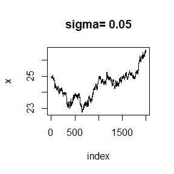

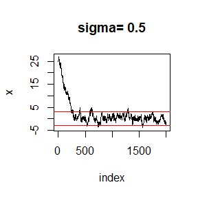

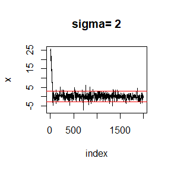

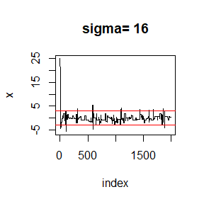

```r
library(Rcpp)
library(microbenchmark)
set.seed(135)

## random walk Metropolis sampler in R
rwMetropolisR <- function(sigma, x0, N) {
  x <- numeric(N)
  x[0] <- x0
  u <- runif(N)
  k <- 0
  for (i in 2:N) {
    y <- rnorm(1, x[i-1], sigma)
    if (u[i] <= ((1/2)*exp(-abs(y))) / ((1/2)*exp(-abs(x[i-1]))))
      x[i] <- y else {
        x[i] <- x[i-1]
        k <- k + 1
      }
  }
  return(list(x=x, k=k))
}

## random walk Metropolis sampler in C++
cppFunction('List rwMetropolisC(double sigma, double x0, int N) {
            NumericVector x(N);
            x[0] = x0;
            int k = 0;
            for(int i = 1; i < N; i++){
              double u = as<double>(runif(1));
              double y = as<double>(rnorm(1, x[i-1], sigma));
              if(u <= exp(-abs(y)+abs(x[i-1])))
              x[i] = y;
              else {
                x[i] = x[i-1];
                k += 1;
              }
            }
            return List::create(x,k);
          }')

N <- 2000; sigma <- c(0.05, 0.5, 2, 16); x0 <- 25

# plots of four chains in C++
index <- 1:2000; refline <- c(log(2*0.025), -log(2*(1-0.975)))
for(i in 1:4){
  y <- unlist(rwMetropolisC(sigma[i], x0, N)[1])
  plot(index, y, type = "l", ylab="x")
  abline(h = refline, lwd = 1, col = 2)
  title(paste("sigma=", sigma[i]))
}
```

```r
# acceptance rates in C++
acceptRateC <- numeric(4)
for(i in 1:4){
  acceptRateC[i] <- 1-(as.numeric(rwMetropolisR(sigma[i], x0, N)[2]))/N
}
print(c(acceptRateC1 = acceptRateC[1], acceptRateC2 = acceptRateC[2], acceptRateC3 = acceptRateC[3], acceptRateC4 = acceptRateC[4]))
```

```
## acceptRateC1 acceptRateC2 acceptRateC3 acceptRateC4
##       0.9810       0.8370       0.5505       0.0825
```

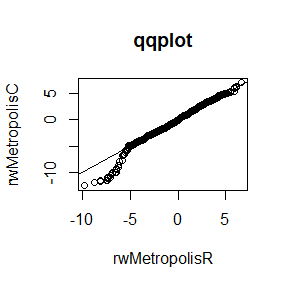

```r
# qqplot
xR <- rwMetropolisR(2, 25, 10000)$x[1000:10000]
xC <- unlist(rwMetropolisC(2, 25, 10000)[1])[1000:10000]
qqplot(xR, xC, main="qqplot", xlab = "rwMetropolisR", ylab = "rwMetropolisC")
abline(a = 0, b = 1)
```

```r
# computation time
ts <- microbenchmark(xR = rwMetropolisR(2, 25, 10000), xC = rwMetropolisC(2, 25, 10000))
summary(ts)[, c(1,3,5,6)]
```

```
##   expr       lq    median        uq
## 1   xR 16.94840 17.463551 18.842351
## 2   xC  1.34585  1.440551  1.524801
```

## Comments

For me, it’s easier to solve this question in R because I’m not quite familiar with the usage of C and C++.

The results in qqplot shows that the generated random numbers are quite near with these two functions. However, the results of computation time show an evident computational speed gain of C++ against R.